# Lightweight Obfuscation (LWO) Transport

# Lightweight Obfuscation (LWO) Transport

**Revision:** 1 **Last modified:** 2026-06-25T00:00:00Z

> Master technical specification — Volume 2 (Data Plane), nano-detail deepening of the **Lightweight Obfuscation (LWO) Transport** introduced at [01-data-plane §3.7]. Scope: keyed obfuscation of the WireGuard header bytes that DPI signatures key on, plus randomized padding — the cheapest obfuscation rung above plain UDP. This is a **SPEC** (describe what to build; do not write the shipping product). Sources cited inline by id: `[01-DP §N]` = the pass-1 data-plane overview; `[04_ARCH §N]` = `HelixVPN-Architecture-Refined.md`; `[04_P0 §N]` = `Phase0-Spike.md`; `[04_P2 §N]` = Phase-2 refined doc; `[SYNTHESIS §N]` = cross-document synthesis; `[WG-PROTOCOL]` = the public WireGuard protocol specification (wireguard.com/protocol, Noise-IK message formats — **external standard**, not the Helix evidence base; every byte offset taken from it is flagged). Anything not groundable is marked `UNVERIFIED` per §11.4.6.

## 0. Position in the system & what this document owns

LWO is one variant of the `Transport` trait [01-DP §3.1] — the single L2 carrier interface shared byte-for-byte by client, connector, and edge (invariant I4) [01-DP §0.1, 04_ARCH §134]. It carries **already-encrypted WireGuard datagrams** (I1) as **unreliable UDP datagrams** (I2): exactly one WG datagram per UDP packet, preserving WG's loss semantics with no head-of-line blocking — the same datagram-preserving property `plain-udp` has and that `shadowsocks` / `udp-over-tcp` lose [01-DP §3.5–§3.6].

LWO is the **first escalation rung above `plain-udp`** in the ladder because it is the cheapest non-default option: near-zero CPU, no QUIC handshake, no extra round trips [01-DP §3.7, 04_ARCH §129/§132/§385]. Default ladder order on a restricted network: `[ plain-udp, lwo, masque-h3, shadowsocks, udp-over-tcp ]` [01-DP §5.3].

**What this document owns:** the LWO wire format (byte layouts, both phase schemes), the key-derivation chain, the obfuscate/deobfuscate algorithms, the per-packet padding policy, the LWO `Transport` impl surface, its state machine, error taxonomy, config knobs, edge cases, security considerations (including the honest limits of cheap obfuscation), the MTU/perf budget, and the test matrix.

**What it does NOT own:** the `Transport` trait itself (frozen at [01-DP §3.1]); WG crypto (`helix-wg`, [01-DP §4]); the ladder selection algorithm (`helix-core/src/ladder.rs`, [01-DP §5.3] — LWO only contributes its `dial()` and `health()`); `NetworkMap` delivery of `session_key` (doc 03); DAITA shaping (a separate L2.5 stage, [01-DP §9] — LWO padding is **not** DAITA and makes no anti-fingerprinting claim beyond defeating the static WG signature).

### 0.1 LWO-specific invariants (extend the §0.1 data-plane set)

[output not shown]

## 1. Threat model — the WireGuard signature LWO defeats

### 1.1 What a passive DPI box keys on (the WG fingerprint)

A WireGuard datagram on the wire begins with a fixed, low-entropy header. Per the public WireGuard protocol [WG-PROTOCOL §5.4] (**external standard — byte offsets below are from the WG spec, not the Helix evidence base; flagged accordingly**):

```
WG message framing (all little-endian):
  byte 0      : message_type   ∈ {1,2,3,4}
  bytes 1..3  : reserved_zero  = 0x00 0x00 0x00   (always three zero bytes)
  bytes 4..   : type-specific payload

  type 1 = Handshake Initiation   — TOTAL 148 bytes (fixed)   [WG-PROTOCOL §5.4.2]
  type 2 = Handshake Response      — TOTAL  92 bytes (fixed)   [WG-PROTOCOL §5.4.3]
  type 3 = Cookie Reply            — TOTAL  64 bytes (fixed)   [WG-PROTOCOL §5.4.7]
  type 4 = Transport Data          — TOTAL ≥ 32 bytes (16B hdr + ≥16B AEAD)  [WG-PROTOCOL §5.4.6]

  Handshake Initiation (type 1) field map [WG-PROTOCOL §5.4.2]:
    [0]      type=1
    [1..4]   reserved = 0,0,0
    [4..8]   sender_index   (u32, little-endian, attacker-observable counter)
    [8..40]  unencrypted_ephemeral (32B Curve25519 point — random-looking)
    [40..88] encrypted_static (48B = 32B + 16B Poly1305 tag — random-looking)
    [88..116] encrypted_timestamp (28B = 12B TAI64N + 16B tag — random-looking)
    [116..132] mac1 (16B keyed-BLAKE2s — random-looking)
    [132..148] mac2 (16B — random-looking or zero)

  Transport Data (type 4) field map [WG-PROTOCOL §5.4.6]:
    [0]      type=4
    [1..4]   reserved = 0,0,0
    [4..8]   receiver_index (u32, little-endian)
    [8..16]  counter (u64, little-endian, MONOTONIC — the strongest plaintext signal)
    [16..]   encrypted_encapsulated_packet (≥16B AEAD — random-looking)
```

Three independent, cheaply-computable DPI signatures fall out of this:

1. **The 4-byte prefix pattern** — `byte[0] ∈ {1,2,3,4}` AND `byte[1..3] == 0x000000`. A single u32 mask/compare per packet flags WG with near-zero false positives against random UDP. **This is the dominant signature.**
2. **Fixed handshake lengths** — a UDP packet of exactly **148 / 92 / 64** bytes to a fresh peer is a near-certain WG handshake, independent of payload [WG-PROTOCOL §5.4].
3. **The transport counter** — `byte[8..16]` of a type-4 packet increments by 1 per packet in a low-loss flow; a monotone little-endian u64 in a fixed offset is a strong stateful tell.

### 1.2 LWO's countermeasures (mapped 1:1 to the signatures)

| Signature | LWO countermeasure | Mechanism (§3) |
| --- | --- | --- |
| (1) 4-byte prefix `{1..4},0,0,0` | XOR-mask the first `header_obf_len` bytes (default 16, ≥ the 4-byte prefix **and** the index/counter fields) with a keystream → prefix becomes uniform-random; the WG signature vanishes. | §3.3 obfuscate |
| (2) fixed lengths 148/92/64 | append `pad_len ∈ [pad_min, pad_max]` keyed-random padding bytes → the 148-byte init becomes a variable-length packet, breaking the fixed-length fingerprint. | §3.4 padding |
| (3) monotone counter at `[8..16]` | covered by (1) when `header_obf_len ≥ 16` — the counter falls inside the XOR-masked prefix and is masked with a per-packet keystream, so it no longer presents as a clean monotone u64. | §3.3 obfuscate (note `header_obf_len` default = 16, not 4, **precisely** to cover the counter) |

After LWO, every UDP packet on the wire is: an 8-byte cleartext random `seed`, followed by a prefix that is uniform-random (masked), followed by WG ciphertext that was already random-looking, followed by random-looking padding of varying length. To the dominant passive WG classifier there is no WG signature left. **Honest boundary (L5):** a *stateful entropy classifier* may still flag "high-entropy UDP to :443-ish with no TLS/QUIC handshake" — LWO does not claim to beat that; that is the escalation to `masque-h3` [01-DP §3.3].

## 2. Where LWO sits — layering & ladder placement

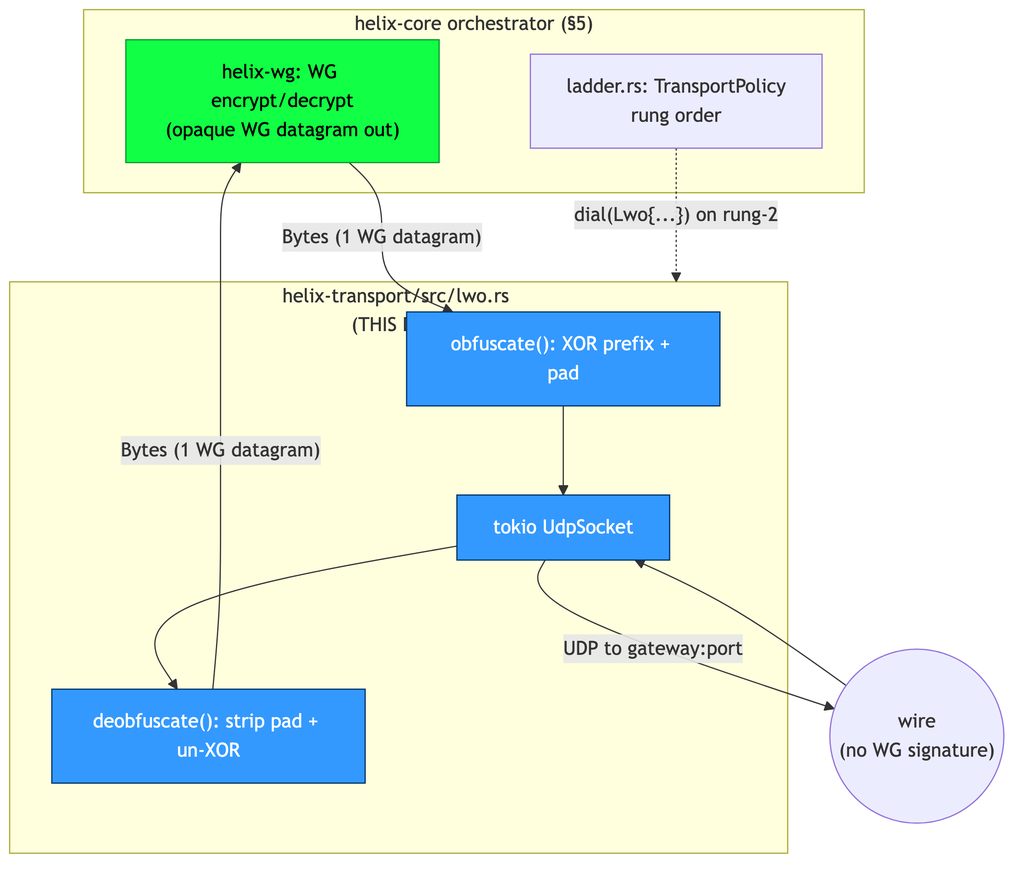

LWO is selected when `plain-udp` (rung 1) exceeds its handshake failure budget — i.e. WG/UDP is being dropped by a signature-matching DPI box [01-DP §5.3 step 3, sequence at §5.4 "Rung 2"]. Because LWO is also UDP, if the censor is dropping *all* UDP (not just WG-signed UDP), LWO will also fail its budget and the ladder escalates to `masque-h3` (TCP/443-shaped QUIC). LWO's value is precisely the **common middle case**: UDP is allowed, but packets carrying the WG signature are dropped.

## 3. Wire format & algorithms

### 3.1 LWO frame layout (on-wire, one per UDP datagram)

```
 0        1        ...      8                       8+L                 8+L+P
 +--------+--------+--------+------------------------+-------------------+
 | seed (8 bytes, cleartext)| obf(WG datagram), L B  | padding, P bytes  |
 +--------+--------+--------+------------------------+-------------------+
 |<------ SEED_LEN=8 ------>|<-- WG datagram (XOR'd  |<-- keyed-random   |
 |  per-packet random nonce |    over first H bytes) |    pad, length P  |
 |  = keystream seed         |    rest = raw WG ct    |    derived from   |
 |                           |    (already random)    |    seed (§3.4)    |
 +---------------------------+------------------------+-------------------+

  SEED_LEN  = 8   (constant)
  L         = true WG datagram length (1 .. effective_mtu_inner); NOT on the wire —
              recovered as  L = udp_payload_len - SEED_LEN - P
  P         = pad_len(seed, pad_key)  ∈ [pad_min, pad_max]   (deterministic from seed; §3.4)
  H         = min(L, header_obf_len)  bytes of the WG datagram that get XOR-masked
  udp_payload_len = SEED_LEN + L + P   (== the bytes UDP hands us; known on recv)
```

**Why no explicit length field:** `P` is a pure deterministic function of `(seed, pad_key)` (§3.4), and `udp_payload_len` is given by the UDP stack, so the receiver recovers `L = udp_payload_len − 8 − P` with **zero** extra header bytes. This minimizes overhead (the entire LWO framing cost is `SEED_LEN + P` = 8 + ~[0..16] bytes) and removes a plaintext length field that would itself be a fingerprint. (Phase 1's simpler variant carries a 1-byte obfuscated `pad_len`; see §3.5.)

### 3.2 Key derivation chain

`session_key: SecretBytes` arrives in `TransportConfig::Lwo` from the coordinator's `NetworkMap` (doc 03), per-peer and rotatable. From it LWO derives two sub-keys via HKDF-SHA256 (RFC 5869):

```rust
// helix-transport/src/lwo.rs  — key schedule
use hkdf::Hkdf;
use sha2::Sha256;

const LWO_INFO_OBF: &[u8] = b"helix-lwo/v2/obf-key";
const LWO_INFO_PAD: &[u8] = b"helix-lwo/v2/pad-key";
const SEED_LEN: usize     = 8;

struct LwoKeys {
    obf_key: [u8; 32],   // ChaCha20 key for the header keystream (§3.3)
    pad_key: [u8; 16],   // keyed PRF key for pad-length derivation (§3.4)
}

/// salt = a per-session 32-byte value also pushed in the NetworkMap (session_salt),
/// rotated whenever session_key rotates; binds the key schedule to one session.
fn derive_keys(session_key: &SecretBytes, session_salt: &[u8; 32]) -> LwoKeys {
    let hk = Hkdf::<Sha256>::new(Some(session_salt), session_key.expose());
    let mut obf_key = [0u8; 32];
    let mut pad_key = [0u8; 16];
    hk.expand(LWO_INFO_OBF, &mut obf_key).expect("hkdf obf");   // 32 ≤ 255*32, infallible
    hk.expand(LWO_INFO_PAD, &mut pad_key).expect("hkdf pad");
    LwoKeys { obf_key, pad_key }
}
```

`SecretBytes` is a zeroize-on-drop wrapper (the same `SecretBytes` used by `TransportConfig::Shadowsocks`/`Lwo` in [01-DP §3.1]); `obf_key`/`pad_key` live in a struct that also implements `Zeroize` on `Drop`. Keys never touch logs (§11.4.10).

### 3.3 The keystream & header obfuscation (Phase 2 — hardened)

```rust
use chacha20::cipher::{KeyIvInit, StreamCipher};
use chacha20::ChaCha20;   // IETF ChaCha20: 32B key, 12B nonce, 32-bit block counter

/// Derive a 12-byte ChaCha20 nonce from the 8-byte per-packet seed.
/// First 4 nonce bytes are a fixed domain tag so the same seed never collides
/// with the pad-PRF input space; last 8 are the seed.
#[inline]
fn seed_to_nonce(seed: &[u8; SEED_LEN]) -> [u8; 12] {
    let mut n = [0u8; 12];
    n[0..4].copy_from_slice(b"OBF1");
    n[4..12].copy_from_slice(seed);
    n
}

/// Obfuscate IN PLACE: XOR the first H = min(L, header_obf_len) bytes of `wg`
/// with the ChaCha20 keystream. Cost: one ChaCha20 init + H bytes of XOR (H ≤ 64
/// by default → a single ChaCha20 block). The remaining L-H bytes are untouched
/// (already-random WG ciphertext, no signature).
fn obfuscate_header(keys: &LwoKeys, seed: &[u8; SEED_LEN], wg: &mut [u8], header_obf_len: usize) {
    let h = wg.len().min(header_obf_len);
    let mut cipher = ChaCha20::new((&keys.obf_key).into(), (&seed_to_nonce(seed)).into());
    cipher.apply_keystream(&mut wg[..h]);   // XOR mask; deobfuscate is the identical op
}
```

**Deobfuscation is the identical operation** (XOR is its own inverse): re-derive the keystream from the cleartext `seed` and `obf_key`, XOR the first `H` bytes of the recovered `L`-byte WG region. No separate code path.

**`header_obf_len` default = 16** (config §11): covers the 4-byte prefix, the 4-byte sender/receiver index, and (for type-4) the 8-byte counter — i.e. *every* low-entropy / monotone field in §1.1, in a single ChaCha20 block's worth of XOR. A `full` mode (`header_obf_len = u16::MAX`, clamped to `L`) XORs the entire datagram for maximum entropy flattening at a slightly higher (still linear, ~1 GB/s/core) cost; default stays header-only because the WG body is already random (L1, §1.1).

### 3.4 Padding policy (keyed, deterministic from seed)

```rust
use siphasher::sip::SipHasher13;   // fast keyed PRF; pad_key is the SipHash key
use std::hash::Hasher;

/// pad_len is a DETERMINISTIC function of (seed, pad_key): the sender and receiver
/// compute the identical value with no length field on the wire.
/// Range [pad_min, pad_max] inclusive; both config knobs (§11). pad_max - pad_min + 1
/// MUST be ≥ 1.  Uniform over the range via rejection-free modulo on a 64-bit PRF
/// (bias ≤ 2^-58 for ranges ≤ 256 — negligible for a length distribution).
fn pad_len(keys: &LwoKeys, seed: &[u8; SEED_LEN], pad_min: u16, pad_max: u16) -> usize {
    let span = (pad_max - pad_min) as u64 + 1;
    let mut h = SipHasher13::new_with_key(&{
        let mut k = [0u8; 16]; k.copy_from_slice(&keys.pad_key); k
    });
    h.write(b"PAD1");
    h.write(seed);
    (pad_min as u64 + (h.finish() % span)) as usize
}

/// Padding CONTENT is keystream bytes (high-entropy, indistinguishable from the body),
/// generated from the same ChaCha20 stream advanced past the header region. Receiver
/// never needs to read padding content — it strips P bytes by length only (L4).
fn fill_padding(keys: &LwoKeys, seed: &[u8; SEED_LEN], out: &mut [u8]) {
    let mut cipher = ChaCha20::new((&keys.obf_key).into(), (&seed_to_nonce(seed)).into());
    // advance the cipher past the 64-byte header block so padding ≠ header keystream reuse
    let mut skip = [0u8; 64];
    cipher.apply_keystream(&mut skip);
    for b in out.iter_mut() { *b = 0; }
    cipher.apply_keystream(out);   // out becomes pure keystream (random-looking)
}
```

**Padding length distribution:** uniform `[pad_min, pad_max]` per packet, keyed so a passive observer cannot predict or remove it. Defaults `pad_min = 0`, `pad_max = 16` (config §11). The WG handshake's three fixed lengths (148/92/64) thus spread across 17 distinct on-wire lengths each. **Optional length-equalization mode** (`pad_to_bucket`, §11): instead of a uniform range, pad each packet up to the next bucket boundary (e.g. multiples of 64) so the length histogram collapses to a few buckets — a stronger anti-length-fingerprint at higher average overhead. Default is the cheap uniform mode (L5: LWO is the *cheap* rung; bucket mode is the bridge toward DAITA [01-DP §9] without being DAITA).

### 3.5 Phase 1 (basic) scheme — `scheme_version = 1`

Phase 1 ships before the full keyed keystream is hardened [01-DP §3.7]. It MUST interoperate on the same frame layout (§3.1) so the Phase-2 upgrade is a keystream swap, not a wire-format break:

- **Header mask:** a *static* 32-byte mask `M = HKDF(session_key, "helix-lwo/v1/mask")`, XORed over the first `H` bytes. `seed` is still present and still randomizes `pad_len`, but the header keystream does **not** depend on `seed` → identical header bytes mask to identical ciphertext across packets (the known weakness).
- **pad_len:** carried as a 1-byte field at frame offset 8, XORed with `M[0]` (so the explicit length variant of §3.1). Recovered as `P = wire[8] ^ M[0]`; the WG region starts at offset 9.
- **Honest limit (documented in code + tracker):** the static mask is vulnerable to known-plaintext recovery — an adversary who knows the WG header structure (public) can XOR two captured LWO packets to cancel `M` and recover header deltas, then solve for `M`. Phase 1 LWO therefore defeats *only* a stateless signature-matcher that does not do this analysis, and is flagged `Operator-blocked`-grade for any active adversary until `scheme_version = 2` lands. This is stated, not hidden (§11.4.6, L5).

The orchestrator MUST refuse to negotiate `scheme_version = 1` once a peer advertises `2` in its `NetworkMap` capability set (doc 03); v1 exists only for the Phase-1 milestone window.

### 3.6 Send / receive packet flow

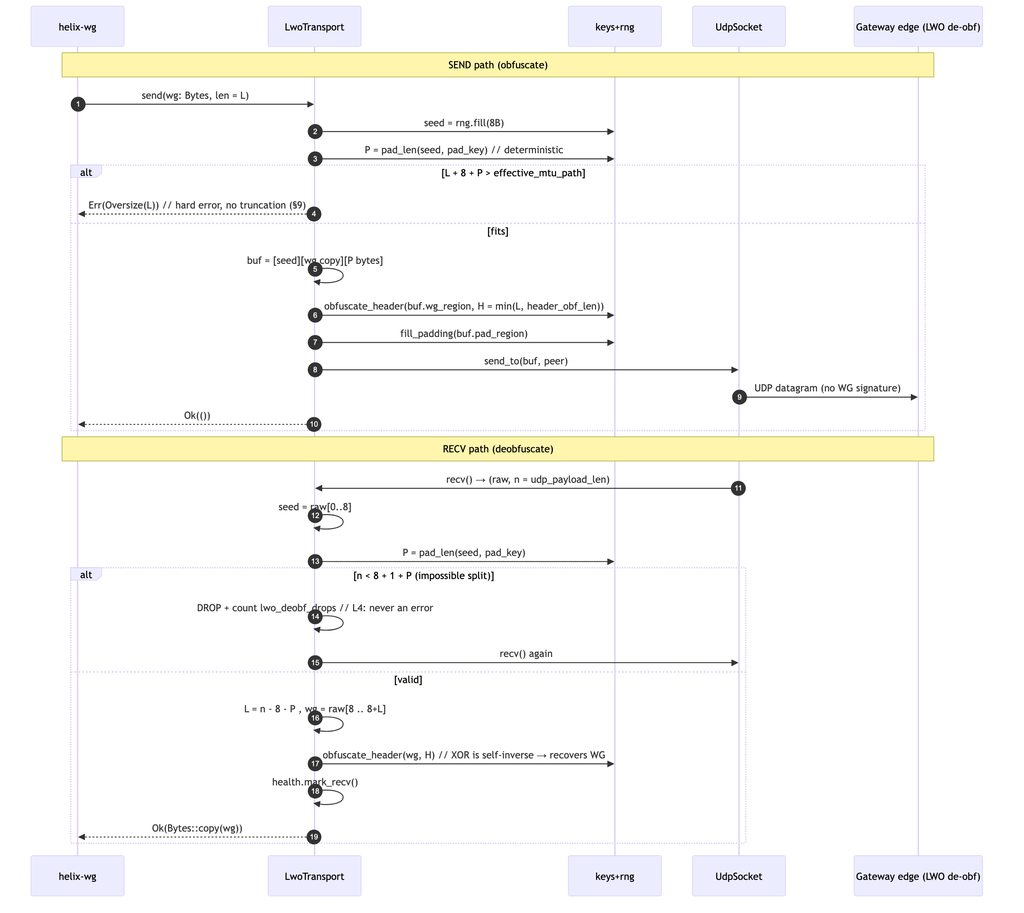

## 4. Rust API surface (the LWO `Transport` impl)

```rust
// helix-transport/src/lwo.rs
use async_trait::async_trait;
use bytes::Bytes;
use std::net::SocketAddr;
use std::sync::atomic::{AtomicU64, Ordering};
use crate::{Transport, TransportError, TransportHealth};
use crate::health::HealthCell;     // shared with plain_udp (RTT EWMA, last-recv age)

/// Lightweight WG obfuscation carrier. Per-packet stateless on the data path (L2);
/// the only mutable state is the HealthCell and an optional monotonic send counter
/// used to refresh seeds under a (negligible) collision-avoidance policy.
pub struct LwoTransport {
    sock:    tokio::net::UdpSocket,
    peer:    SocketAddr,
    keys:    LwoKeys,                 // zeroized on drop (§3.2)
    cfg:     LwoParams,               // header_obf_len, pad_min/max, scheme_version (§11)
    health:  HealthCell,
    send_ctr: AtomicU64,              // mixed into the seed RNG to harden against seed reuse
    drops:   AtomicU64,               // lwo_deobf_drops counter (L4, metrics §11.4.5)
}

/// Tunable obfuscation parameters; all come from TransportConfig::Lwo / NetworkMap.
#[derive(Clone, Copy, Debug)]
pub struct LwoParams {
    pub scheme_version: u8,   // 1 = static mask (Phase 1, §3.5); 2 = keyed keystream (§3.3)
    pub header_obf_len: u16,  // default 16 (covers prefix+index+counter, §3.3)
    pub pad_min: u16,         // default 0
    pub pad_max: u16,         // default 16  (must be ≥ pad_min)
    pub pad_to_bucket: u16,   // 0 = uniform range; else round length up to this multiple (§3.4)
}

impl Default for LwoParams {
    fn default() -> Self {
        Self { scheme_version: 2, header_obf_len: 16, pad_min: 0, pad_max: 16, pad_to_bucket: 0 }
    }
}

/// Construct from the dial() ladder (§5.3). Binds a UDP socket, derives keys.
/// Validated: pad_max ≥ pad_min, header_obf_len ≥ 4, scheme_version ∈ {1,2}.
pub(crate) async fn dial_lwo(
    peer: SocketAddr, bind: SocketAddr,
    session_key: SecretBytes, session_salt: [u8; 32], cfg: LwoParams,
) -> Result<LwoTransport, TransportError> {
    if cfg.pad_max < cfg.pad_min || cfg.header_obf_len < 4 || !(1..=2).contains(&cfg.scheme_version) {
        return Err(TransportError::HandshakeFailed("invalid LwoParams".into()));
    }
    let sock = tokio::net::UdpSocket::bind(bind).await?;
    sock.connect(peer).await?;        // connected UDP: lets recv() drop off-path datagrams cheaply
    Ok(LwoTransport {
        sock, peer,
        keys: derive_keys(&session_key, &session_salt),
        cfg, health: HealthCell::new(), send_ctr: AtomicU64::new(0), drops: AtomicU64::new(0),
    })
}

#[async_trait]
impl Transport for LwoTransport {
    async fn send(&self, wg: Bytes) -> Result<(), TransportError> {
        let l = wg.len();
        if l == 0 { return Ok(()); }                                   // §9 edge: empty → no-op
        let seed = self.next_seed();                                   // 8B, ctr-mixed RNG
        let p = self.pad_len(&seed);
        let total = SEED_LEN + l + p;
        if total > self.effective_mtu() as usize + SEED_LEN /*hdr is accounted in eff_mtu*/ {
            return Err(TransportError::Oversize(l));                   // §9: never truncate
        }
        let mut buf = Vec::with_capacity(total);
        buf.extend_from_slice(&seed);
        buf.extend_from_slice(&wg);
        buf.resize(total, 0);
        self.obfuscate(&seed, &mut buf[SEED_LEN..SEED_LEN + l]);       // §3.3
        self.fill_padding(&seed, &mut buf[SEED_LEN + l..]);            // §3.4
        self.sock.send(&buf).await?;                                  // connected UDP
        Ok(())
    }

    async fn recv(&self) -> Result<Bytes, TransportError> {
        let mut buf = vec![0u8; (self.effective_mtu() as usize) + SEED_LEN + self.cfg.pad_max as usize + 64];
        loop {
            let n = self.sock.recv(&mut buf).await?;                   // cancel-safe (I2)
            match self.deobfuscate(&buf[..n]) {
                Some(wg) => { self.health.mark_recv(); return Ok(wg); }
                None => { self.drops.fetch_add(1, Ordering::Relaxed); continue; } // L4: drop+loop
            }
        }
    }

    fn kind(&self) -> &'static str { "lwo" }
    fn effective_mtu(&self) -> u16 { 1400 }    // plain-udp 1420 − SEED_LEN(8) − ~12 pad headroom (§10)
    fn health(&self) -> TransportHealth { self.health.snapshot() }
    async fn close(&self) -> Result<(), TransportError> { Ok(()) } // UDP: nothing to flush
}
```

```rust
// private helpers (sketch)
impl LwoTransport {
    fn next_seed(&self) -> [u8; SEED_LEN] {
        // 8 random bytes from a CSPRNG, mixed with the monotonic send counter so that
        // even a (broken) RNG returning a repeat cannot reuse a full seed within a session.
        let ctr = self.send_ctr.fetch_add(1, Ordering::Relaxed);
        let mut s = [0u8; SEED_LEN];
        rand::rng().fill_bytes(&mut s);
        let cb = ctr.to_le_bytes();
        for i in 0..SEED_LEN { s[i] ^= cb[i]; }     // counter is non-secret; only de-dups seeds
        s
    }
    fn pad_len(&self, seed: &[u8; SEED_LEN]) -> usize {
        let p = pad_len(&self.keys, seed, self.cfg.pad_min, self.cfg.pad_max);
        if self.cfg.pad_to_bucket == 0 { p } else { /* round-up-to-bucket variant, §3.4 */ p }
    }
    fn obfuscate(&self, seed: &[u8; SEED_LEN], region: &mut [u8]) {
        match self.cfg.scheme_version {
            2 => obfuscate_header(&self.keys, seed, region, self.cfg.header_obf_len as usize),
            _ => obfuscate_header_static_v1(&self.keys, region, self.cfg.header_obf_len as usize),
        }
    }
    fn fill_padding(&self, seed: &[u8; SEED_LEN], out: &mut [u8]) { fill_padding(&self.keys, seed, out); }

    /// Returns None ⇒ DROP (L4): never an error, never tears the tunnel down.
    fn deobfuscate(&self, raw: &[u8]) -> Option<Bytes> {
        if raw.len() < SEED_LEN + 1 { return None; }
        let mut seed = [0u8; SEED_LEN]; seed.copy_from_slice(&raw[..SEED_LEN]);
        let p = self.pad_len(&seed);
        if raw.len() < SEED_LEN + p + 1 { return None; }     // pad can't exceed payload (with ≥1 WG byte)
        let l = raw.len() - SEED_LEN - p;
        if l == 0 || l > self.effective_mtu() as usize { return None; }   // sanity bound
        let mut wg = raw[SEED_LEN..SEED_LEN + l].to_vec();
        self.obfuscate(&seed, &mut wg[..wg.len().min(self.cfg.header_obf_len as usize)]); // self-inverse
        Some(Bytes::from(wg))
    }
}
```

### 4.1 `TransportConfig` & `dial()` wiring

LWO is already a variant of the frozen `TransportConfig` enum [01-DP §3.1]:

```rust
// (from helix-transport/src/lib.rs — UNCHANGED, shown for context)
Lwo { peer: SocketAddr, bind: SocketAddr, session_key: SecretBytes },
```

This document **proposes the additive fields** `session_salt: [u8; 32]` and `params: LwoParams` on the `Lwo` variant so the coordinator can push the salt and per-region obfuscation tuning (`UNVERIFIED`: the pass-1 enum at [01-DP §3.1] shows only `peer/bind/session_key`; whether these two extra fields are added to the public enum or carried in a side-channel is a doc-03 `NetworkMap` schema decision — flagged for reconciliation when doc 03 lands). The `dial()` ladder routes `TransportConfig::Lwo{..}` → `dial_lwo()` (§4).

## 5. State machine

LWO has almost no connection state (it is connectionless UDP), but the orchestrator-visible lifecycle and the key-rotation path are state-machine-worthy:

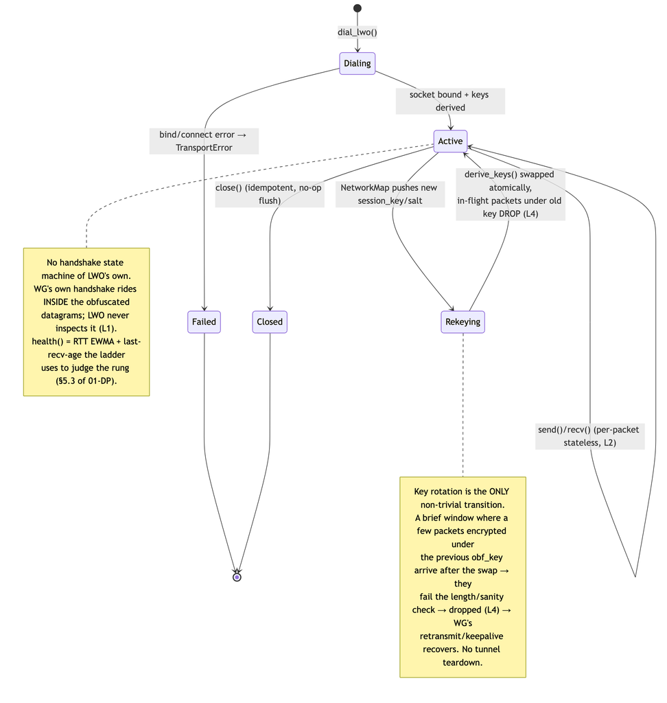

**Rekeying detail:** `derive_keys()` produces a fresh `LwoKeys`; the swap is a single `ArcSwap<LwoKeys>` (or `Mutex<LwoKeys>`) replacement. There is **no** negotiated cutover — LWO carries no control messages. Packets in flight under the old key deobfuscate to a wrong `L`/`P` and are dropped (L4); the WG layer above does not even notice (its own keepalive/retransmit [01-DP §4 `tick`] covers the ≤ RTT gap). Rekey cadence is a coordinator policy (`rekey_interval`, §11); default rotation aligns with WG's own rekey (~120 s) so an LWO-key and a WG-key rotation coincide, minimizing distinct key-lifetime windows. `UNVERIFIED`: the exact coordinator rekey push mechanism is doc-03 territory.

## 6. Error taxonomy

LWO reuses the shared `TransportError` [01-DP §3.1, error.rs] and adds **no new public variant** (keeping the trait surface uniform). Mapping:

| Condition | Surfaced as | Path | Notes |
| --- | --- | --- | --- |
| `bind`/`connect` UDP socket failure at dial | `TransportError::Io` | `dial_lwo` | propagates to the ladder → escalate rung (§5.3) |
| invalid `LwoParams` (pad_max<pad_min, header_obf_len<4, bad scheme) | `TransportError::HandshakeFailed("invalid LwoParams")` | `dial_lwo` | a config error reads as a handshake failure → ladder skips LWO |
| `send()` of a datagram that won't fit `eff_mtu` after seed+pad | `TransportError::Oversize(L)` | `send` | hard error, **never truncates** (§9); orchestrator lowers inner WG MTU |
| socket send/recv I/O error mid-session | `TransportError::Io` | `send`/`recv` | repeated → health degrades → ladder may re-escalate |
| a received packet fails deobfuscation (bad length split, sanity bound, probe traffic) | **NOT an error** — dropped + `lwo_deobf_drops++` | `recv` (loops) | **L4**: corrupt/probe/old-key packets must not kill a live tunnel |
| internal deobf logic invariant broken (would be a bug) | `debug_assert!` in debug; drop in release | `deobfuscate` | §11.4.1 — a script/logic bug must never masquerade as a product FAIL |

There is deliberately **no `DeobfuscationFailed` public error**: per L4 a failed deobfuscation is indistinguishable, from LWO's standpoint, from random noise/probe traffic, and the correct response is silent drop, not tunnel teardown.

## 7. Edge cases (enumerated, each with the defined behavior)

[output not shown]

## 8. Security considerations (honest boundary — §11.4.6, L5)

1. **What LWO IS for:** defeating a *stateless, signature-matching* DPI box that blocks UDP packets exhibiting the WG fingerprint (§1.1 signatures 1–3). Against that adversary, Phase-2 LWO removes all three signals at near-zero cost.
2. **What LWO is NOT for** (stated, never overclaimed):
   - *Active probing.* A censor that replays/probes the gateway endpoint is not defeated by LWO (LWO has no anti-probe response). The anti-probe story is the `masque-h3` decoy site [01-DP §3.3].
   - *Stateful entropy / flow classifiers.* "High-entropy UDP, no TLS/QUIC handshake, periodic small packets" can still cluster. `pad_to_bucket` (§3.4) helps marginally; full defense is DAITA [01-DP §9] + `masque-h3`. LWO makes **no traffic-analysis claim**.
   - *Confidentiality / integrity.* LWO is **obfuscation, not encryption** — the WG datagram it wraps already provides AEAD confidentiality+integrity (I1). LWO's XOR keystream is NOT a security boundary; a recovered `obf_key` reveals only the (already-encrypted) header bytes, never WG plaintext (L3). LWO MUST NOT be relied on for any security property WG does not already provide.
3. **Phase-1 static-mask weakness** (§3.5): known-plaintext recovery of the static mask. Phase-1 LWO is a milestone artifact; it ships flagged and is auto-superseded by v2 (E9). Tracked as a known limitation, never presented as production-grade obfuscation.
4. **Seed reuse → keystream reuse** (E7): bounded to `≈2^-64` per packet pair by the 8-byte CSPRNG seed + counter mix; even on reuse only the masked *header* prefix leaks an XOR delta, not WG plaintext. Acceptable for the cheap rung; `masque-h3` is the answer where this risk is unacceptable.
5. **Key separation** (L3): `obf_key`/`pad_key` derive from a transport `session_key` distinct from WG keys, with their own salt and rotation; an LWO key compromise is contained to deobfuscation, never WG.
6. **Replay / amplification:** LWO neither adds nor mitigates replay beyond WG's own counter (WG drops replayed transport packets). LWO is not a reflection/amplification vector — it is a 1:1 datagram wrapper with no response generation of its own.
7. **No logging:** `lwo_deobf_drops` and health are aggregate counters only (I5, §11.4.5); no per-packet/per-peer durable state.

## 9. MTU & overhead budget

LWO's wire overhead per packet = `SEED_LEN(8) + P(pad_len)`. With defaults `pad_max = 16`, the worst-case overhead is `8 + 16 = 24` bytes; average `8 + 8 = 16`. Reconciling with [01-DP §10] (which lists `lwo ≈ 1400`):

[output not shown]

Rules (inherit [01-DP §10]):

**CPU budget (the "near-zero" claim, [04_ARCH §129]):** per packet = one CSPRNG draw (8 B) + one SipHash-1-3 (pad_len) + one ChaCha20 init + XOR of `H ≤ 64` bytes (header mode) + ChaCha20 of `P ≤ 16` padding bytes. All sub-microsecond on a modern core; the dominant cost remains the UDP syscall, shared with `plain-udp`. Target: LWO throughput ≥ **95%** of `plain-udp` throughput (the cheap-rung promise) — measured, not assumed (§12 PT/BT). This is far below `masque-h3`'s QUIC overhead, which is exactly LWO's reason to exist [01-DP §3.7].

## 10. Config knobs (operator + coordinator surface)

| Knob | Type | Default | Source | Effect |
| --- | --- | --- | --- | --- |
| `scheme_version` | `u8` ∈ {1,2} | `2` | NetworkMap | 1 = Phase-1 static mask (§3.5); 2 = keyed keystream (§3.3). v1 auto-superseded (E9). |
| `header_obf_len` | `u16` (≥4) | `16` | NetworkMap | bytes of the WG datagram XOR-masked; 16 covers prefix+index+counter (§3.3); `u16::MAX`→full-datagram mask. |
| `pad_min` | `u16` | `0` | NetworkMap | floor of the uniform padding range. |
| `pad_max` | `u16` (≥ pad_min) | `16` | NetworkMap | ceil of the uniform padding range; 0 disables padding (E3). |
| `pad_to_bucket` | `u16` | `0` | NetworkMap | 0 = uniform range; N = round each on-wire length up to a multiple of N (stronger length-equalization, §3.4). |
| `rekey_interval` | `Duration` | `120 s` | coordinator | LWO key-rotation cadence; default aligned to WG rekey (§5). |
| `session_key` | `SecretBytes` | — (required) | NetworkMap | root of the key schedule (§3.2); per-peer, rotatable. |
| `session_salt` | `[u8;32]` | — (required) | NetworkMap | binds the key schedule to one session; rotates with `session_key`. |
| `bind` | `SocketAddr` | `0.0.0.0:0` | client config | local UDP bind (ephemeral by default). |

Seed length (`SEED_LEN = 8`), the HKDF info strings, and the ChaCha20/SipHash choices are **compile-time constants**, not knobs — changing them is a wire-format break requiring a `scheme_version` bump (kept out of the runtime config surface deliberately).

`UNVERIFIED`: the precise field placement of `header_obf_len`/`pad_*`/`pad_to_bucket` in the `NetworkMap` schema is doc-03 territory; this doc fixes their semantics and defaults, doc 03 fixes their transport.

## 11. Region/ladder integration (read-only dependencies)

- **Ladder rung:** LWO is `order[1]` in the restricted-network prior (§2); the coordinator may push a regional prior that starts directly at `lwo` for regions where naive WG-signature blocking is common but UDP is otherwise open, so users skip the plain-udp failure round-trip [01-DP §5.3 step 5].
- **Per-network memory:** on a successful LWO connection the ladder remembers (SSID / gateway fingerprint → start at `lwo`) so reconnects on the same hostile network skip straight to it [01-DP §5.3 step 4]. LWO contributes only `health()`; the memory lives in `ladder.rs`.
- **Telemetry:** "lwo succeeded after N escalations in region R" — aggregate only, feeds the Censorship-Evasion Success dashboard [01-DP §5.3 step 6, 04_ARCH §416]; plus `lwo_deobf_drops` as a health signal. No per-user data (I5).

## 12. Test matrix (§11.4.169 test types — anti-bluff captured evidence)

> `UNVERIFIED`: §11.4.169 is named by the operator as the test-type taxonomy but is not present in the constitution text loaded for this session (loaded anchors end at §11.4.168). The concrete test types below are grounded in the canonical enumeration of §11.4.27 (unit / integration / e2e / full-automation / security / DDoS / scaling / chaos / stress / performance / benchmarking) + §11.4.85 (stress+chaos) + §11.4.5/.69/.107 (captured evidence). The mapping is presented under the §11.4.169 label as instructed; reconcile the anchor number when §11.4.169 is available.

[output not shown]

Every PASS uses `ab_pass_with_evidence` citing the artifact path (§11.4.69); a config-only / grep-only PASS is a covenant violation. The **G2-class wire-fingerprint check** (`tshark` classifies the flow with no WG signature [01-DP §12.1]) is the central anti-bluff gate for LWO, exactly as it is for `masque-h3`.

## 13. File-by-file build checklist (LWO slice)

[output not shown]

Phasing matches [01-DP §12]: `lwo` is **Phase 1 (basic, §3.5) → Phase 2 (hardened, §3.3)**.

## 14. Out of scope for this document

The `Transport` trait, `TransportHealth`, `TransportError` definitions (frozen, [01-DP §3.1]); the ladder selection algorithm and per-network memory store ([01-DP §5.3], `ladder.rs` — LWO is a consumer); `NetworkMap` delivery of `session_key`/`session_salt`/`LwoParams` and the exact schema field placement (doc 03); WG crypto and the WG handshake state machine ([01-DP §4]); DAITA shaping ([01-DP §9] — LWO padding is a cheap length-fingerprint breaker, **not** DAITA and makes no traffic-analysis claim, L5); `masque-h3` / `shadowsocks` / `udp-over-tcp` (sibling transports, [01-DP §3.3/§3.5/§3.6]); the coordinator rekey-push mechanism and regional-prior policy source (control plane, doc 02/03).

*End of LWO transport specification (Volume 2, Data Plane). Pairs with [01-DP §3.7] (the rung it deepens), [01-DP §5.3] (the ladder that selects it), and doc 03 (`WatchNetworkMap` — the live source of `session_key`/`session_salt`/`LwoParams`). The frame layout (§3.1), key schedule (§3.2), and the `Transport` impl surface (§4) are the implementation-ready contracts; the Phase-1→Phase-2 path is a keystream swap on a stable wire format (§3.5).*